##### Title: **Analyze the ToothGrowth data in the R datasets package**

##### Author: **Thomas NG Jia Chee**

##### Date: **20 October 2015**

## Overview

This project analyzes the ToothGrowth data in the R datasets package. It consists of 3 parts:

1. A basic summary of the data
2. Confidence intervals and hypothesis tests to compare tooth growth by **supplement type** and **quantity of dose**
3. Conclusions and the assumptions taken

## 1. A Basic Summary of Tooth Growth data

```r
# load dataset
library(datasets)
data("ToothGrowth")

# structure of dataset
str(ToothGrowth)
```

```
## 'data.frame':    60 obs. of  3 variables:
##  $ len : num  4.2 11.5 7.3 5.8 6.4 10 11.2 11.2 5.2 7 ...
##  $ supp: Factor w/ 2 levels "OJ","VC": 2 2 2 2 2 2 2 2 2 2 ...
##  $ dose: num  0.5 0.5 0.5 0.5 0.5 0.5 0.5 0.5 0.5 0.5 ...
```

```r
# summary of dataset
summary(ToothGrowth)
```

```
##       len        supp         dose
##  Min.   : 4.20   OJ:30   Min.   :0.500
##  1st Qu.:13.07   VC:30   1st Qu.:0.500
##  Median :19.25           Median :1.000
##  Mean   :18.81           Mean   :1.167
##  3rd Qu.:25.27           3rd Qu.:2.000
##  Max.   :33.90           Max.   :2.000
```

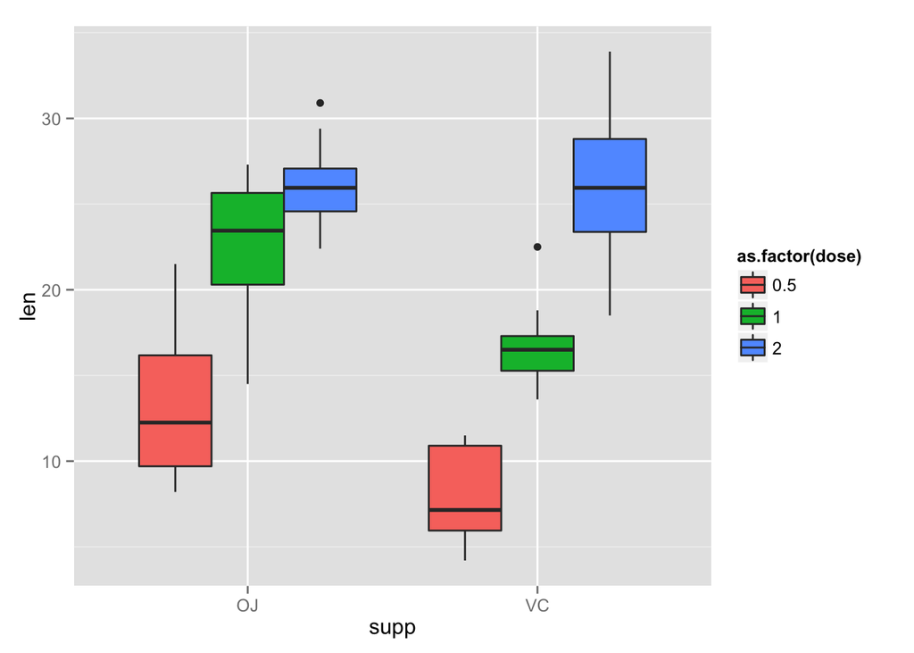

```r
# explore data using graphical method, using ggplot2
library(ggplot2)
# a quick plot to compare supplement type & quantity of dose
qplot(supp, len, data=ToothGrowth, geom=c('boxplot'), fill=as.factor(dose))
```

The observation from the graph is

1. **Supplement type does not have strong correlation with tooth growth.**
2. **Higher amount of supplement dose may stimulate tooth growth.**

## 2. Confidence intervals and hypothesis tests

#### Part 2.1: The correlation between supplement type and tooth growth

> Null hypothesis states that supplement has no significant difference in stimulating tooth growth. T-test is conducted at 5% significance level.

```r
# use t-test to compare tooth growth by supplement type
t.test(len ~ supp, data = ToothGrowth)
```

```
##
##  Welch Two Sample t-test
##
## data:  len by supp
## t = 1.9153, df = 55.309, p-value = 0.06063
## alternative hypothesis: true difference in means is not equal to 0
## 95 percent confidence interval:
##  -0.1710156  7.5710156
## sample estimates:
## mean in group OJ mean in group VC
##         20.66333         16.96333
```

T-test shown that, at 95 percent confience interval,

1. P-value is 6%, higher than 5%.
2. Confidence interval contains 0

**Thus, null hypothesis CANNOT be rejected. Supplement type does not have strong correlation with tooth growth.**

#### Part 2.2: The correlation between quantity of dose and tooth growth

> Null hypothesis states that quantity of dose has no significant difference in stimulating tooth growth. T-test is conducted at 5% significance level.

```r
# To determine correlation of quantity of dose with tooth growth, subset groups based on dose levels, using package 'dplyr'
# There 3 groups (3 Choose 2):
library(dplyr)
group_one <- filter(ToothGrowth, dose %in% c(0.5,1))
group_two <- filter(ToothGrowth, dose %in% c(0.5,2))
group_three <- filter(ToothGrowth, dose %in% c(1,2))

# conduct t-test for all groups
t.test(len ~ dose, data=group_one)
```

```
##
##  Welch Two Sample t-test
##
## data:  len by dose
## t = -6.4766, df = 37.986, p-value = 1.268e-07
## alternative hypothesis: true difference in means is not equal to 0
## 95 percent confidence interval:
##  -11.983781  -6.276219
## sample estimates:
## mean in group 0.5   mean in group 1
##            10.605            19.735
```

```r
t.test(len ~ dose, data=group_two)
```

```
##
##  Welch Two Sample t-test
##
## data:  len by dose
## t = -11.799, df = 36.883, p-value = 4.398e-14
## alternative hypothesis: true difference in means is not equal to 0
## 95 percent confidence interval:
##  -18.15617 -12.83383
## sample estimates:
## mean in group 0.5   mean in group 2
##            10.605            26.100
```

```r
t.test(len ~ dose, data=group_three)
```

```
##
##  Welch Two Sample t-test
##
## data:  len by dose
## t = -4.9005, df = 37.101, p-value = 1.906e-05
## alternative hypothesis: true difference in means is not equal to 0
## 95 percent confidence interval:
##  -8.996481 -3.733519
## sample estimates:
## mean in group 1 mean in group 2
##          19.735          26.100
```

**Thus, null hypothesis CAN be rejected. Higher quantity of dose stimulates tooth growth.**

## 3. Conclusions and assumptions taken

In conclusion,

1. Supplement type does not have strong correlation with tooth growth.
2. Higher quantity of dose stimulates tooth growth.

The conclusions drawn from above t-test are based on the following assumptions,

- Bivariate independent variable (A, B groups)
- Continuous dependent variable
- Each observation of the dependent variable is independent of the other observations of the dependent variable (its probability distribution isn’t affected by their values).

Source: http://www.csic.cornell.edu/Elrod/t-test/t-test-assumptions.html